# Child Doc 7: Alpha Diversity

Grace Rubin

2025-01-21

## 3.b. Overview

**Motivation:** Late pregnancy is often associated with a reduction in maternal gut microbial alpha diversity, a pattern similarly observed in individuals with metabolic syndrome. This overlap has led researchers to hypothesize that gestational declines in alpha diversity may contribute to the shared metabolic alterations seen in both conditions. To investigate whether gestational changes in gut microbial alpha diversity are driven by placental hormones, we conducted a longitudinal analysis in non-pregnant mice treated with placental growth hormone (PGH) or placental lactogen (PL).

For all gut microbiome analyses, I will only be focusing on the non-abx mice. The purpose of including abx mice in the MFC2 study design was to quantify the *metabolic* effects of each hormone with and without a typical gut microbiome. While this design also allows us to examine the effects of the ampicillin + enrofloxacin cocktail on gut microbiome composition, that’s not the focus of this project and will not be included here.

I’ll be analyzing alpha diversity through both the **Chao1** and **Shannon** indices. These indices are calculated differently and provide complementary insights into alpha diversity. **Chao1** is a richness-based index that estimates the total number of species / OTUs in a sample, accounting for rare, lower abundance taxa. **Shannon** index incorporates both richness and evenness, emphasizing more abundant taxa and de-emphasizing rare taxa.

## 3.b.i. Longitudinal changes in alpha diversity across each group

### Chao1

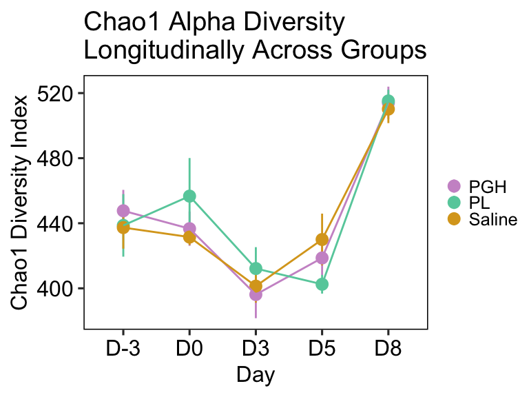

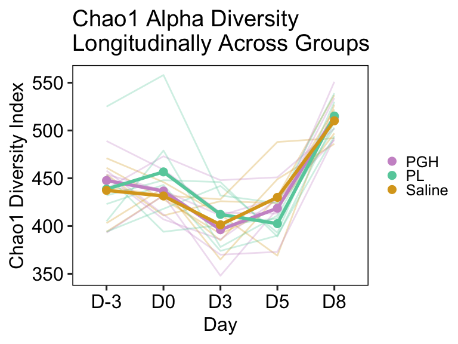

Because we are getting signals of contamination on day 8, we can opt to make day 5 our endpoint instead.

### Shannon

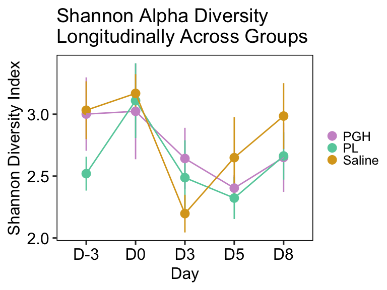

[figure not shown]

To me, it appears that day is the biggest driver of changes in alpha diversity, with similar patterns across time in all three groups (saline, PGH, PL) for both indices.

## 3.b.ii. Baseline vs Intervention Alpha Diversity

### Chao1

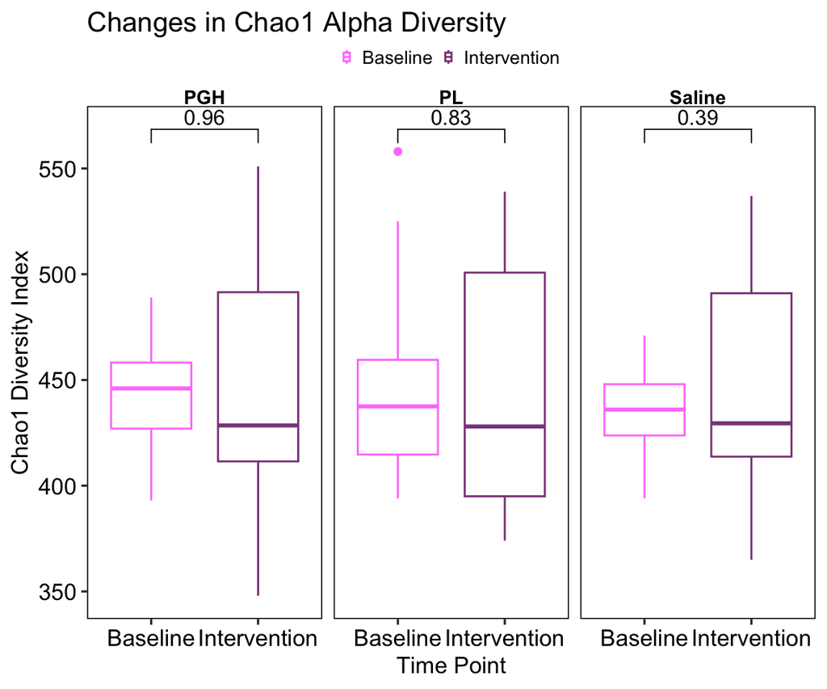

We can also look at just D0 to D5, rather than combining D-3 and D0 as baseline and D3 and D5 as intervention:

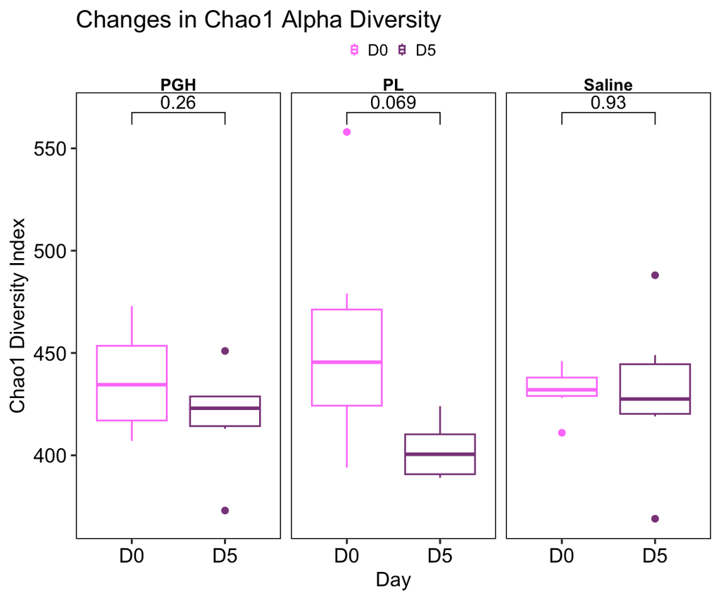

We also can do the same as above but comparing hormone groups at each time point or day, rather than looking longitudinally within the same group:

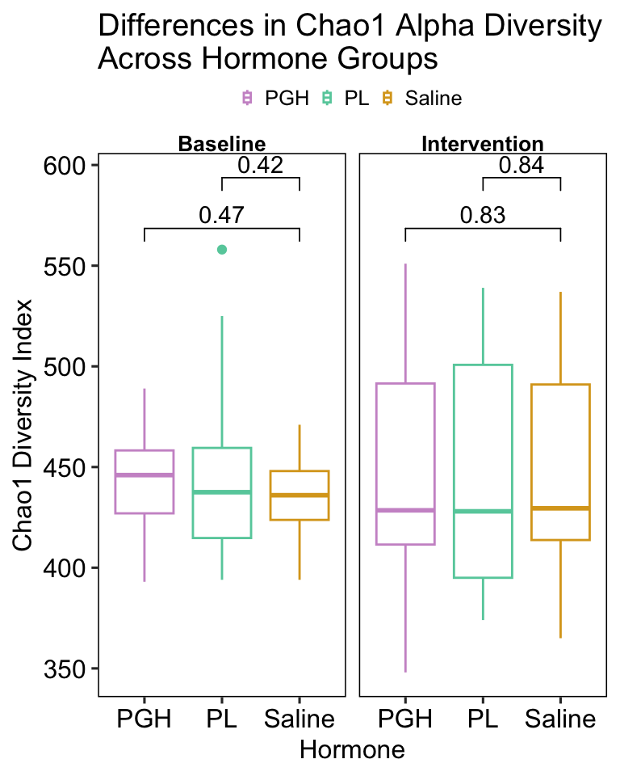

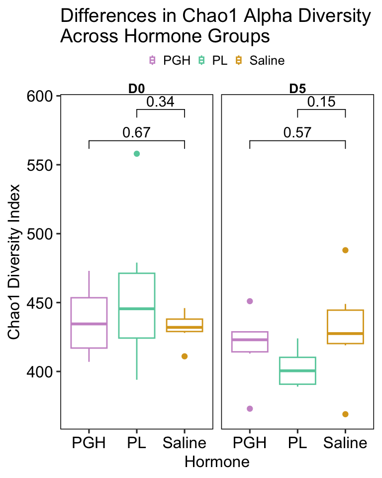

### Shannon

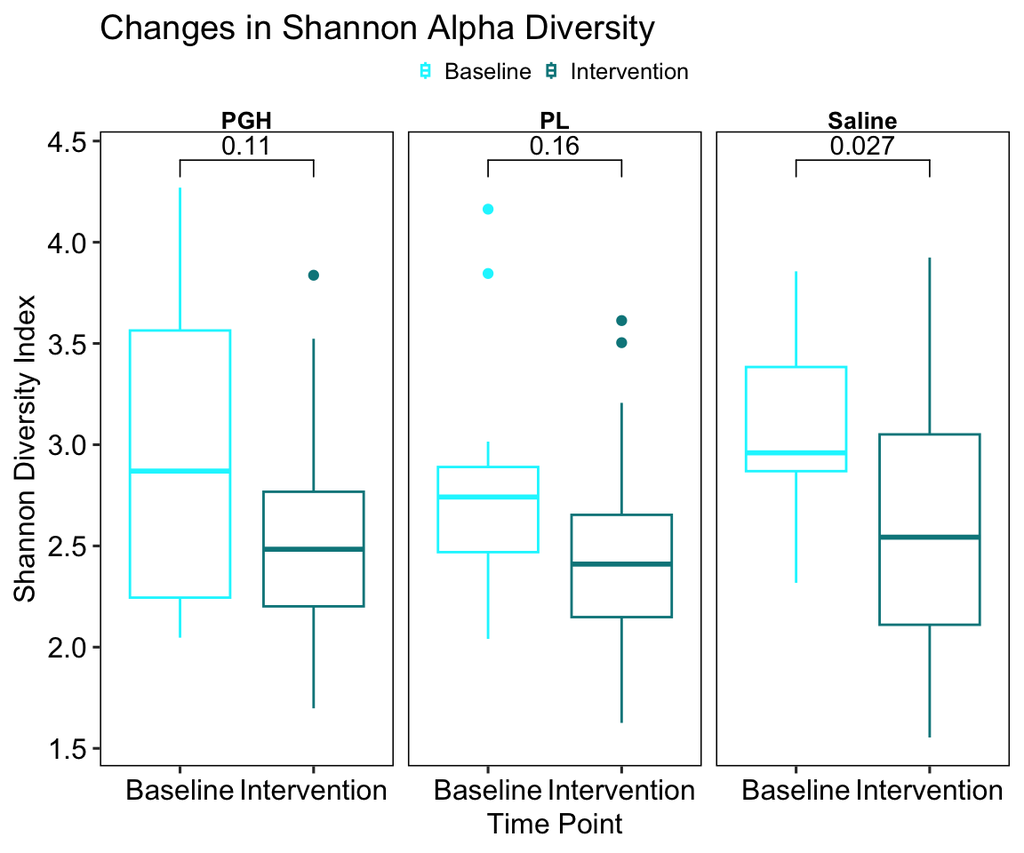

We can also look at just D0 to D5, rather than combining D-3 and D0 as baseline and D3 and D5 as intervention:

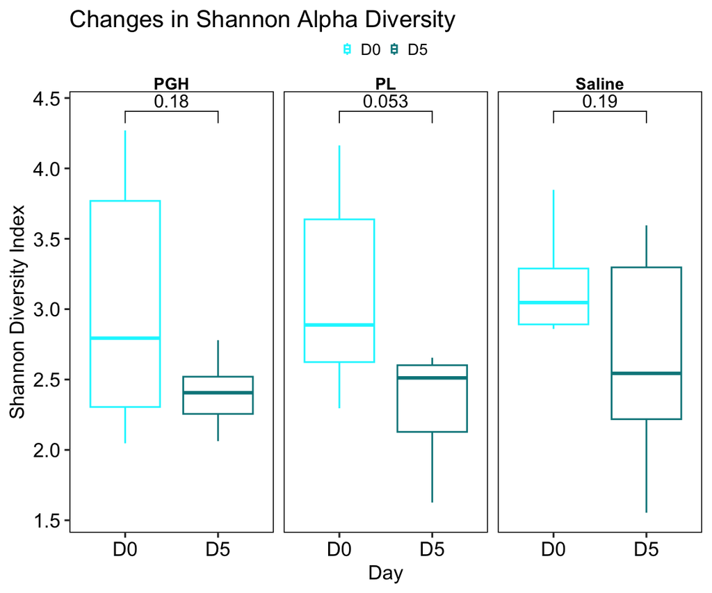

We also can do the same as above but comparing hormone groups at each time point or day, rather than looking longitudinally within the same group:

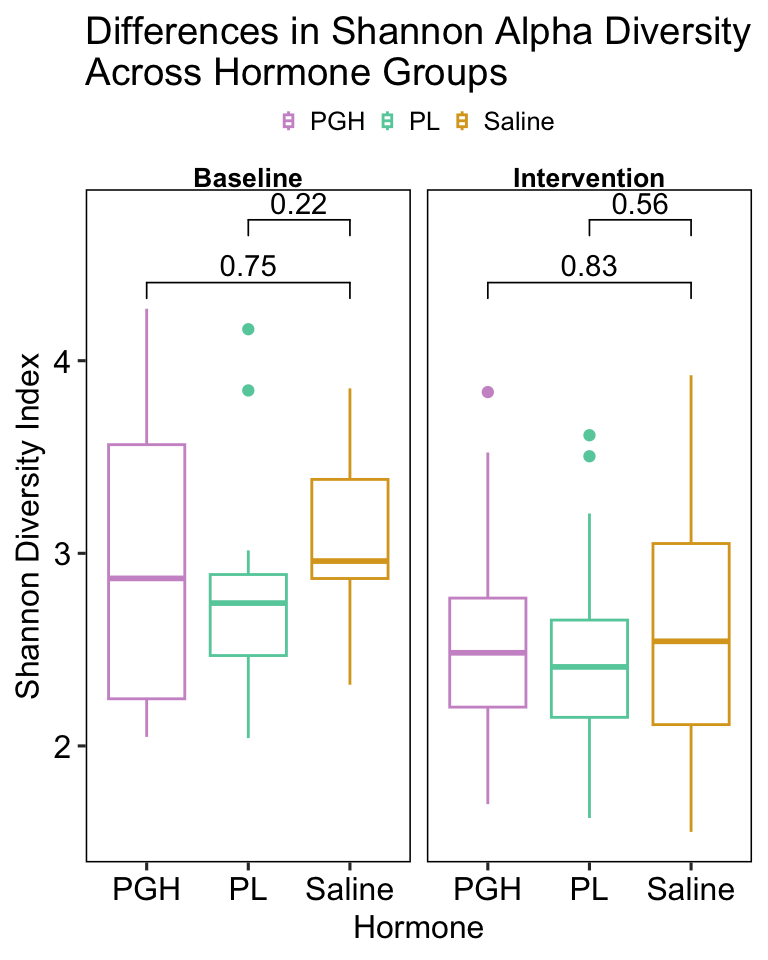

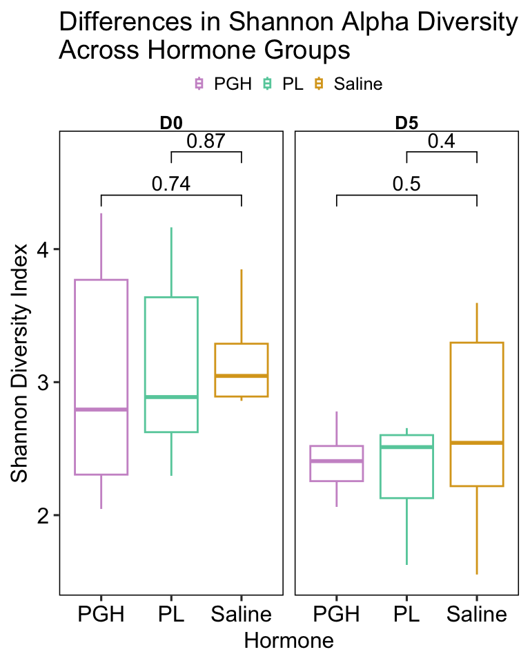

*Takeaway:* There are no consistent changes in alpha diversity driven by placental hormone exposure.